# Exploratory Analysis for Wine from the Vinho Verde Region

#### Looking at ALL of the variables coefficients and their corresponding p-value

Looking at the p-values for each correlation coefficient, there does appear to some relationship between quality and: 1. fixed.acidity 2. volatile.acidity 3. citric.acid 4. chlorides 5. free.sulfur.dioxide 6. total.sulfur.dioxide 7. density 8. pH 9. sulphates 10. alcohol

**although in many of the cases above the coefficient itself was small (which may indicate that no relationship exists), since the p-value is also small (below alpha=0.05) then this tells us that some relationship may exist. Further analysis will show if the variables above truly influence the response. There is 1 variable showing that no relationship exists with quality, according to the high p-value:

No relationship with quality: 1. residual.sugar

Note that there are predictors that appear to possibly have a relationship with other predictors. I will have to look at the VIFs as well as watch for other signs that may indicate multicollinearity.

```r
##Are any of the predictors highly correlated?

variables <- colnames(redwine)

for (i in 1:11)  #first variable comparing
{
  for (j in (i+1):12) #second variable comparing
  {
    print(paste(variables[i],variables[j])) #printing first and second variable that is being compared
    corr <- (cor.test(redwine[,i],redwine[,j])) #cor.test returns correlation coeff with p-value, returns those for corresponding pairs
    print(paste(corr$estimate,corr$p.value)) #print corr estimate and p-value for simplicity
  }
}
```

```
## [1] "fixed.acidity volatile.acidity"
## [1] "-0.256130894770382 2.27672044317663e-25"
## [1] "fixed.acidity citric.acid"
## [1] "0.671703434764106 2.53532106182069e-210"
## [1] "fixed.acidity residual.sugar"
## [1] "0.114776724494921 4.1994648676827e-06"
## [1] "fixed.acidity chlorides"
## [1] "0.0937051863213054 0.000175174597854262"
## [1] "fixed.acidity free.sulfur.dioxide"
## [1] "-0.153794192864825 6.3355794505297e-10"
## [1] "fixed.acidity total.sulfur.dioxide"
## [1] "-0.113181443045481 5.70903285658013e-06"
## [1] "fixed.acidity density"
## [1] "0.668047292118974 3.07474706085687e-207"
## [1] "fixed.acidity pH"
```

[output cut: 117 more lines]

#### Focusing on quality, the target response

No predictors are highly correlated with quality. The predictors in the center are less likely to be useful in this model, because they are the furthest from 1 (perfect positive) and -1 (perfect negative).

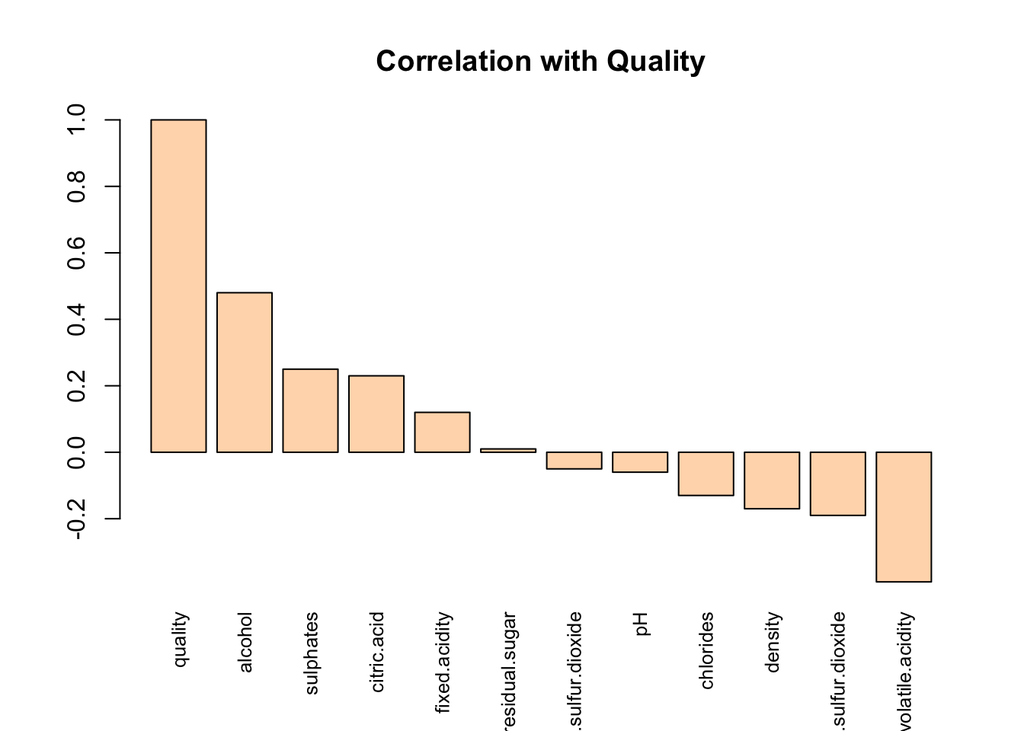

```r
par(mfrow=c(1,1), las=3)
barplot(sort(pears_corr[,12], decreasing=TRUE), col="peachpuff", cex.names=0.8, main="Correlation with Quality")
```

The predictors most strongly correlated with Quality are:

- alcohol
- volatile acidity

Other predictors that may influence Quality are:

- sulphates
- citric acid

### Simple Linear Regression

Because there are no highly correlated predictors with the response variable, I am forgoing simple linear regression modeling, so that I may begin to determine if I can predict the qualilty of wine using the chemical properties of wine.